# Primera Práctica

# Simulación de procesos

## Proceso de Wiener

En este código simularemos un proceso de Wiener Generalizado y observaremos la variable que siga un comportamiento de ese tipo

$$dW = \epsilon\sqrt{dt}$$

**Donde:**

$\epsilon ~ N(0,1)$

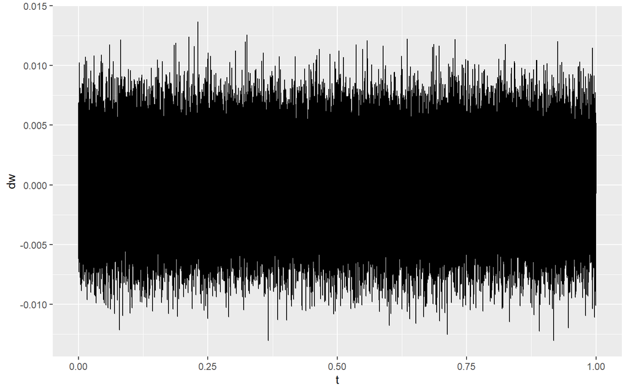

[figure not shown]

```r
datos <- tibble(t=seq(1/sim,1,by=dt),dw)
ggplot(datos)+
  geom_line(aes(x=t,y=dw))
```

¿cómo sería W?
$$W_t = W_{t-1} +dW_t$$

```r
W <- 0
W[1] <- 0
for (t in 2:sim){
  W[t] = W[t-1]+dw[t]
}
datos <- mutate(datos,W=W)
```

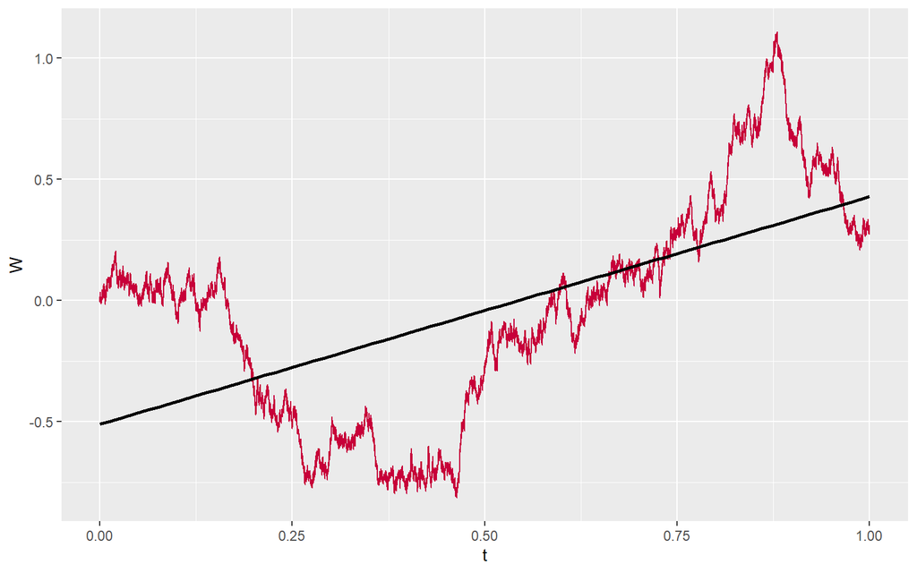

## Proceso de Wiener Generalizado

En este caso
$$dX = adt+bdw$$

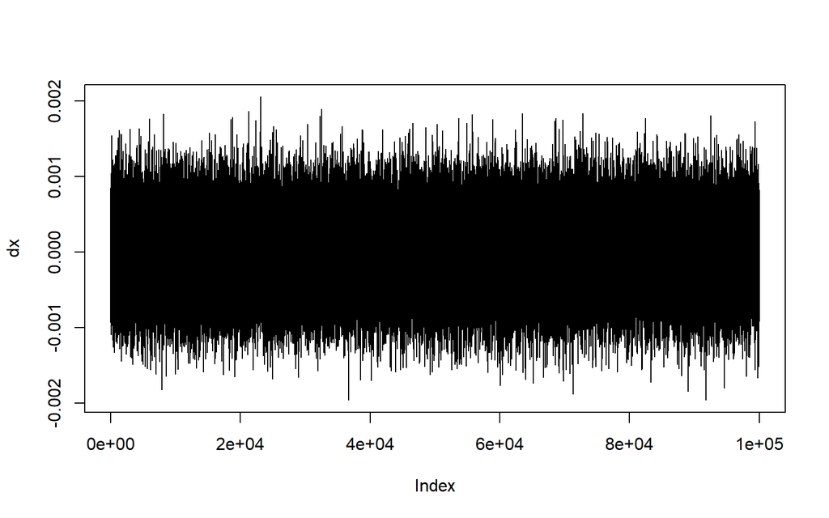

```r
a <- 0.3
b <- 0.15
dx <-  a*dt+b*dw
plot(dx,type = 'l')
```

Ahora X, sería
$$X_t = X_{t-1}+dX_t$$

```r
X <- 0
X[1] <-0
for (t in 2:sim){
  X[t] = X[t-1]+dx[t]
}
datos <- mutate(datos,X=X)
```

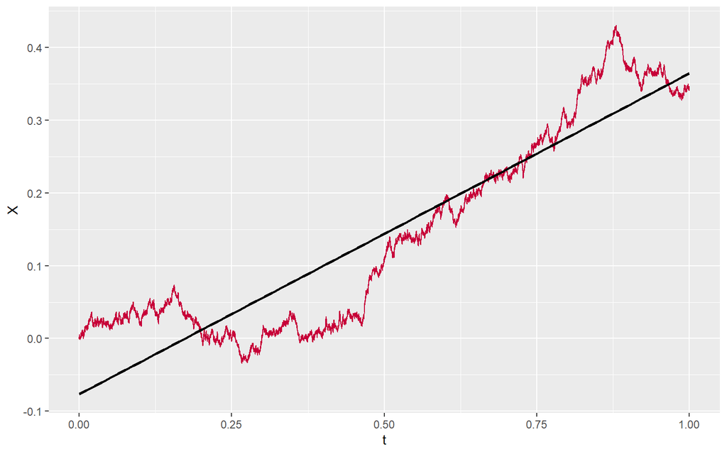

## Resolviendo un problema

Una determinada variable sigue un proceso de WG con una drift rate de 2 y una tasa de varianza de 4. Ambas con unidad de tiempo semestral. Si el día de hoy la variable X toma el valor de 50. 1 año
$$dX = 4+2\sqrt{2} \epsilon$$
$$X=50+dX$$
$$X=54+2\sqrt{2}\epsilon$$
¿Cuál es el valor esperado y la varianza de X dentro de 1 año?

```r
dxa <- 4+2*sqrt(2)*epsilon
Xa <- 50+dxa
```

```r
mean(Xa)
```

```
## [1] 54.00276
```

```r
var(Xa)
```

```
## [1] 7.995735
```

```r
mean(dxa<0)
```

```
## [1] 0.07861
```

```r
mean((50<Xa)&(Xa<=51))
```

```
## [1] 0.06557
```